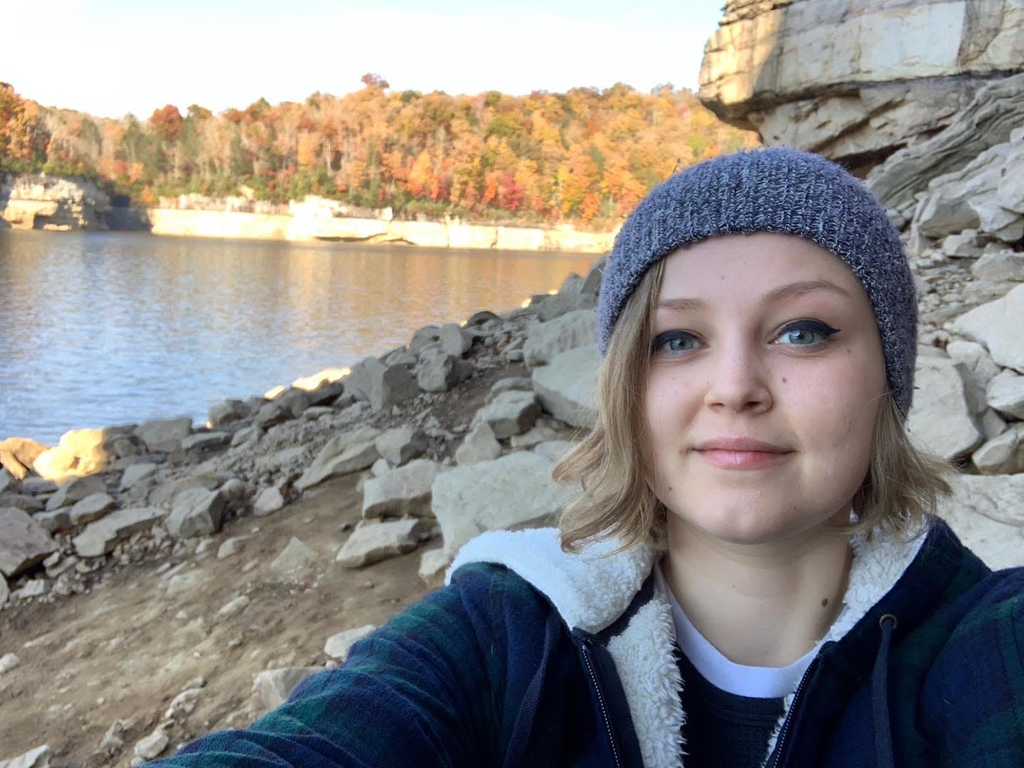

# Anya Nazarenko

## Bio

Anya Nazarenko is a member of the research staff at the Begun Center for Violence Prevention Research and Education at Case Western Reserve University. Her research focuses primarily on the interactions between law enforcement and individuals with mental illness. She is currently the research coordinator for the City of Cleveland Police Co-Responder Program and a member of the Cleveland Division of Police Consent Decree Data Team.

## Education

**Case Western Reserve University** | Cleveland, OH

Graduate Studies | September 2022 - May 2024

**Case Western Reserve University** | Cleveland, OH

B.A. in Psychology | September 2009 - May 2013

## Experience

**Case Western Reserve University** | Research Assistant 4 | January 2020 - Present

- Conduct comprehensive program evaluations of projects, including interviews with program participants and in-depth analyses of all data collected
- Oversee data acquisition, database preparation, data entry, data cleaning/management, and data analysis and visualization for projects
- Maintain relationships with community partners to monitor evaluation progress and improve data collection techniques
- Engage in dissemination activities related to the research projects

**The Centers for Families and Children** | Mental Health Case Manager | March 2018 - December 2019

- Assessed clients’ mental health needs and coordinated treatment with other mental health staff
- Facilitated clients’ development of daily living skills
- Provided mental health interventions to clients that addressed symptoms, behaviors, and thought processes to eliminate barriers to seeking or maintaining education or employment
- Advocated on behalf of clients within various community settings
- Coordinated and assisted clients during crisis management and stabilization